# Dungca_Asessment3

```python
import numpy as np
import pandas as pd
import seaborn as sns
import matplotlib.pyplot as plt
from sklearn.model_selection import train_test_split
import statsmodels.api as sm
from sklearn.datasets import fetch_openml
from sklearn.linear_model import LogisticRegression, LinearRegression
from statsmodels.stats.diagnostic import het_breuschpagan
from statsmodels.stats.stattools import jarque_bera
from sklearn.preprocessing import LabelEncoder
from sklearn.preprocessing import StandardScaler
from sklearn.feature_selection import SelectKBest, f_classif
from statsmodels.genmod.families import Binomial
from statsmodels.stats.outliers_influence import summary_table
from statsmodels.stats.outliers_influence import variance_inflation_factor
from sklearn.metrics import (classification_report, confusion_matrix,
                           accuracy_score, precision_score, recall_score,
                           f1_score, roc_auc_score, roc_curve,
                           precision_recall_curve)
import statsmodels.formula.api as smf
from scipy import stats
import warnings
warnings.filterwarnings('ignore')
```

```python
#Set random seed for reproducibility
np.random.seed(42)

#Configure plotting style
plt.style.use('default')
sns.set_palette("husl")
```

```python
#Load Dataset through fetch ID
datas = fetch_openml(data_id = 43436, as_frame = True, parser = 'pandas')
print("Data Loaded")
df = datas.data.copy()
df.info()
```

```
Data Loaded
<class 'pandas.DataFrame'>
RangeIndex: 32561 entries, 0 to 32560
Data columns (total 15 columns):
 #   Column          Non-Null Count  Dtype
---  ------          --------------  -----
 0   age             32561 non-null  int64
 1   workclass       30725 non-null  str
 2   fnlwgt          32561 non-null  int64
 3   education       32561 non-null  str
 4   education.num   32561 non-null  int64
 5   marital.status  32561 non-null  str
 6   occupation      30718 non-null  str
 7   relationship    32561 non-null  str
 8   race            32561 non-null  str
 9   sex             32561 non-null  str
 10  capital.gain    32561 non-null  int64
 11  capital.loss    32561 non-null  int64
 12  hours.per.week  32561 non-null  int64
 13  native.country  31978 non-null  str
 14  income          32561 non-null  str
dtypes: int64(6), str(9)
memory usage: 3.7 MB
```

```python
#Null handling
df.replace('?', np.nan, inplace = True)
df['income'].unique()
```

```
<StringArray>
['=50K', '50K']
Length: 2, dtype: str
```

```python
#After further inspection of the dataset I concluded that the equal sign are the only ones with the less than sign so
#I substituted the values that are missing for readability purposes
df['income'] = df['income'].replace({
    "50K": ">50K",
    "=50K": "<=50K"
})
#Make the target value column
df['high_income'] = df['income'] == ">50K"
df['high_income'] = df['high_income'].astype(int)
print(df['high_income'])
```

```
0        0
1        0
2        0
3        0
4        0
        ..
32556    0
32557    0
32558    1
32559    0
32560    0
Name: high_income, Length: 32561, dtype: int64
```

```python
#Make dummy columns for the categorical values and drop the original columns at the same time
#Make sure to do this in another copy of the data so that you have a backup
dfdum = df.copy()

dfdum = pd.concat([dfdum.drop('workclass', axis=1),
                   pd.get_dummies(dfdum['workclass'], dtype=int, prefix='work')], axis=1)
dfdum = pd.concat([dfdum.drop('education', axis=1),
                   pd.get_dummies(dfdum['education'], dtype=int, prefix='education')], axis=1)
dfdum = pd.concat([dfdum.drop('marital.status', axis=1),
                   pd.get_dummies(dfdum['marital.status'], dtype=int, prefix='marital_status')], axis=1)
dfdum = pd.concat([dfdum.drop('occupation', axis=1),
                   pd.get_dummies(dfdum['occupation'], dtype=int, prefix='occupation')], axis=1)
dfdum = pd.concat([dfdum.drop('relationship', axis=1),
                   pd.get_dummies(dfdum['relationship'], dtype=int, prefix='relationship')], axis=1)
dfdum = pd.concat([dfdum.drop('race', axis=1),
                   pd.get_dummies(dfdum['race'], dtype=int, prefix='race')], axis=1)
dfdum = pd.concat([dfdum.drop('sex', axis=1),
                   pd.get_dummies(dfdum['sex'], dtype=int, prefix='sex')], axis=1)

#Seperate the top 5 countries by frequency and the rest will be combined into another column named others
top5_countries = dfdum['native.country'].value_counts().nlargest(5).index
dfdum['native.country_reduced'] = dfdum['native.country'].where(dfdum['native.country'].isin(top5_countries),'Other_countries')
dfdum = pd.concat([dfdum.drop('native.country', axis=1),
                   pd.get_dummies(dfdum['native.country_reduced']
                                  ,prefix='country',dtype=int)],axis=1)
dfdum = dfdum.drop('native.country_reduced', axis=1)
```

I used a code to find the VIF that are more than 5 and dropped them

```python
# Separate features and target
X = dfdum.drop(['income','high_income'], axis=1)  # replace 'income' with your target column
y = dfdum['high_income']

# Function to calculate VIF
def calculate_vif(X):
    vif_data = pd.DataFrame()
    vif_data['Feature'] = X.columns
    vif_data['VIF'] = [variance_inflation_factor(X.values, i) for i in range(X.shape[1])]
    return vif_data

# Iteratively drop features with VIF > 5
max_vif = 5
while True:
    vif_df = calculate_vif(X)
    max_vif_value = vif_df['VIF'].max()
    if max_vif_value <= max_vif:
        break
    drop_feature = vif_df.sort_values('VIF', ascending=False)['Feature'].iloc[0]
    print(f"Dropping {drop_feature} with VIF = {max_vif_value:.2f}")
    X = X.drop(columns=[drop_feature])
```

```
Dropping education.num with VIF = inf
Dropping work_State-gov with VIF = inf
Dropping education_5th-6th with VIF = inf
Dropping marital_status_Married-civ-spouse with VIF = inf
Dropping relationship_Unmarried with VIF = inf
Dropping country_Mexico with VIF = inf
Dropping sex_Female with VIF = inf
Dropping race_White with VIF = 280.77
Dropping country_United-States with VIF = 54.71
Dropping relationship_Husband with VIF = 36.54
Dropping work_Private with VIF = 19.70
Dropping hours.per.week with VIF = 13.53
Dropping age with VIF = 12.89
Dropping education_HS-grad with VIF = 8.45
Dropping marital_status_Never-married with VIF = 5.97
```

I dropped the columns that are VIF > 5.0 , these are the columns I dropped

- Dropping education.num with VIF = inf
- Dropping work_State-gov with VIF = inf
- Dropping education_5th-6th with VIF = inf
- Dropping marital_status_Married-civ-spouse with VIF = inf
- Dropping relationship_Unmarried with VIF = inf
- Dropping country_Mexico with VIF = inf
- Dropping sex_Female with VIF = inf
- Dropping race_White with VIF = 280.77
- Dropping country_United-States with VIF = 54.71
- Dropping relationship_Husband with VIF = 36.54
- Dropping work_Private with VIF = 19.70
- Dropping hours.per.week with VIF = 13.53
- Dropping age with VIF = 12.89
- Dropping education_HS-grad with VIF = 8.45
- Dropping marital_status_Never-married with VIF = 5.97

```python
print("PREPARING DATA FOR MODELING:")
print("-" * 30)
print(f"Features selected: {X}")
print(f"Target variable: survived")
print(f"Total observations: {len(X)}")
print(f"Missing values in features: {X.isnull().sum().sum()}")

# Check class balance before split
print(f"\nClass distribution in full dataset:")
class_dist = y.value_counts(normalize=True)
print(class_dist)
print(f"Survival rate: {y.mean():.3f}")

# Perform stratified train-test split
X_train, X_test, y_train, y_test = train_test_split(
    X, y,
    test_size=0.3,
    stratify=y
)

#Print the information for readability purposes

print(f"\nTRAIN-TEST SPLIT RESULTS:")
print("-" * 30)
print(f"Training set size: {len(X_train)} ({len(X_train)/len(X)*100:.1f}%)")
print(f"Test set size: {len(X_test)} ({len(X_test)/len(X)*100:.1f}%)")

print(f"\nClass distribution verification:")
print(f"Full dataset survival rate: {y.mean():.4f}")
print(f"Training set survival rate: {y_train.mean():.4f}")
print(f"Test set survival rate: {y_test.mean():.4f}")

print(f"\nTraining set feature statistics:")
print(X_train.describe())
```

```
PREPARING DATA FOR MODELING:
------------------------------
Features selected:        fnlwgt  capital.gain  capital.loss  work_Federal-gov  work_Local-gov  \
0       77053             0          4356                 0               0
1      132870             0          4356                 0               0
2      186061             0          4356                 0               0
3      140359             0          3900                 0               0
4      264663             0          3900                 0               0
...       ...           ...           ...               ...             ...
32556  310152             0             0                 0               0
32557  257302             0             0                 0               0
32558  154374             0             0                 0               0
32559  151910             0             0                 0               0
32560  201490             0             0                 0               0

       work_Never-worked  work_Self-emp-inc  work_Self-emp-not-inc  \
0                      0                  0                      0
1                      0                  0                      0
2                      0                  0                      0
3                      0                  0                      0
4                      0                  0                      0
...                  ...                ...                    ...
32556                  0                  0                      0
32557                  0                  0                      0
32558                  0                  0                      0
32559                  0                  0                      0
32560                  0                  0                      0

       work_Without-pay  education_10th  ...  relationship_Wife  \
0                     0               0  ...                  0
1                     0               0  ...                  0
2                     0               0  ...                  0
3                     0               0  ...                  0
4                     0               0  ...                  0
...                 ...             ...  ...                ...
32556                 0               0  ...                  0
32557                 0               0  ...                  1
32558                 0               0  ...                  0
32559                 0               0  ...                  0
32560                 0               0  ...                  0
```

[output cut: 109 more lines]

```
50%        0.000000      0.000000      1.000000        0.000000
75%        0.000000      0.000000      1.000000        0.000000
max        1.000000      1.000000      1.000000        1.000000

       country_Germany  country_Other_countries  country_Philippines
count     22792.000000             22792.000000         22792.000000
mean          0.004344                 0.070946             0.006537
std           0.065764                 0.256740             0.080591
min           0.000000                 0.000000             0.000000
25%           0.000000                 0.000000             0.000000
50%           0.000000                 0.000000             0.000000
75%           0.000000                 0.000000             0.000000
max           1.000000                 1.000000             1.000000

[8 rows x 55 columns]
```

- After dropping the high VIF values, I proceeded with splitting the train and test and I used simple EDA on the X_train to see which features were left since I dropped a lot of features
- This also helped me to verify if the data was split correctly

```python
lpm_model = LinearRegression()
lpm_model.fit(X_train, y_train)

coefficients = pd.Series(lpm_model.coef_, index=X_train.columns)
large_coef_features = coefficients[coefficients.abs() > 0.5].index
print("Features to drop due to large coefficients (>0.5):")
print(large_coef_features)

X_train_reduced = X_train.drop(columns=large_coef_features)
X_test_reduced = X_test.drop(columns=large_coef_features)

# Refit LPM with reduced features
lpm_model_reduced = LinearRegression()
lpm_model_reduced.fit(X_train_reduced, y_train)
print("\nRefitted LPM with reduced features:")
print(pd.Series(lpm_model_reduced.coef_, index=X_train_reduced.columns))
```

```
Features to drop due to large coefficients (>0.5):
Index([], dtype='str')

Refitted LPM with reduced features:
fnlwgt                                  4.431587e-08
capital.gain                            8.280732e-06
capital.loss                            9.920894e-05
work_Federal-gov                        1.074830e-01
work_Local-gov                         -1.536401e-02
work_Never-worked                      -4.175604e-03
work_Self-emp-inc                       8.189435e-02
work_Self-emp-not-inc                  -3.465809e-02
work_Without-pay                       -1.839143e-01
education_10th                         -4.756693e-02
education_11th                         -2.920748e-02
education_12th                          1.360102e-02
education_1st-4th                      -6.617635e-02
education_7th-8th                      -9.486634e-02
education_9th                          -6.395734e-02
education_Assoc-acdm                    6.151544e-02
education_Assoc-voc                     7.889538e-02
education_Bachelors                     1.619148e-01
education_Doctorate                     4.103911e-01
education_Masters                       2.537374e-01
education_Preschool                    -6.650002e-02
education_Prof-school                   3.347365e-01
education_Some-college                  4.299313e-02
marital_status_Divorced                -5.975770e-02
marital_status_Married-AF-spouse        2.902607e-02
marital_status_Married-spouse-absent   -5.208861e-02
marital_status_Separated               -6.466021e-02
marital_status_Widowed                 -1.226244e-02
occupation_Adm-clerical                 2.592377e-02
occupation_Armed-Forces                -2.329298e-01
occupation_Craft-repair                 2.743446e-02
occupation_Exec-managerial              1.879645e-01
occupation_Farming-fishing             -6.912832e-02
occupation_Handlers-cleaners           -4.572618e-02
occupation_Machine-op-inspct           -1.744648e-02
occupation_Other-service               -1.417687e-02
occupation_Priv-house-serv              4.911560e-02
occupation_Prof-specialty               1.002352e-01
occupation_Protective-serv              1.030122e-01
occupation_Sales                        8.114369e-02
occupation_Tech-support                 1.084210e-01
occupation_Transport-moving             1.742682e-02
relationship_Not-in-family             -1.951275e-01
relationship_Other-relative            -1.864795e-01
relationship_Own-child                 -2.373730e-01
relationship_Wife                       2.066914e-01
race_Amer-Indian-Eskimo                -5.847693e-02
race_Asian-Pac-Islander                -4.025346e-02
race_Black                             -3.780792e-02
race_Other                             -5.849453e-02
sex_Male                                1.387760e-01
country_Canada                          1.409450e-02
country_Germany                         5.844047e-02
country_Other_countries                -4.273983e-02
country_Philippines                     6.990327e-02
dtype: float64
```

```python
#Use lpm as the data is binary, linear regression would think that the r squared is low since the values are always low
#LPM will be the compatible model so we will be using that

print("FITTING LINEAR PROBABILITY MODEL (LPM) USING OLS:")
print("-" * 50)

# Add constant term for intercept (required by statsmodels)
X_train_const = sm.add_constant(X_train)
X_test_const = sm.add_constant(X_test)

# Fit the Linear Probability Model using OLS
lpm_model = sm.OLS(y_train, X_train_const)
lpm_results = lpm_model.fit()

print(f"\nMODEL FITTING COMPLETE:")
print(f"- Estimation method: Ordinary Least Squares (OLS)")
print(f"- Number of observations: {lpm_results.nobs}")
print(f"- Number of parameters: {len(lpm_results.params)}")
print(f"- Degrees of freedom: {lpm_results.df_resid}")
```

```
FITTING LINEAR PROBABILITY MODEL (LPM) USING OLS:
--------------------------------------------------

MODEL FITTING COMPLETE:
- Estimation method: Ordinary Least Squares (OLS)
- Number of observations: 22792.0
- Number of parameters: 56
- Degrees of freedom: 22736.0
```

Making an LPM model for comparison with the logistic models

```python
# Fit the LPM OLS regression model
print("LINEAR PROBABILITY MODEL RESULTS:")
print("-" * 40)
print(lpm_results.summary())
```

```
LINEAR PROBABILITY MODEL RESULTS:
----------------------------------------
                            OLS Regression Results
==============================================================================
Dep. Variable:            high_income   R-squared:                       0.337
Model:                            OLS   Adj. R-squared:                  0.335
Method:                 Least Squares   F-statistic:                     210.0
Date:                Sat, 07 Feb 2026   Prob (F-statistic):               0.00
Time:                        17:17:43   Log-Likelihood:                -8295.0
No. Observations:               22792   AIC:                         1.670e+04
Df Residuals:                   22736   BIC:                         1.715e+04
Df Model:                          55
Covariance Type:            nonrobust
========================================================================================================
                                           coef    std err          t      P>|t|      [0.025      0.975]
--------------------------------------------------------------------------------------------------------
const                                    0.1095      0.013      8.571      0.000       0.084       0.135
fnlwgt                                4.432e-08   2.22e-08      1.998      0.046    8.32e-10    8.78e-08
capital.gain                          8.281e-06   3.13e-07     26.484      0.000    7.67e-06    8.89e-06
capital.loss                          9.921e-05   5.76e-06     17.232      0.000    8.79e-05       0.000
work_Federal-gov                         0.1075      0.014      7.636      0.000       0.080       0.135
work_Local-gov                          -0.0154      0.010     -1.535      0.125      -0.035       0.004
work_Never-worked                       -0.0042      0.175     -0.024      0.981      -0.347       0.338
work_Self-emp-inc                        0.0819      0.013      6.258      0.000       0.056       0.108
work_Self-emp-not-inc                   -0.0347      0.009     -3.791      0.000      -0.053      -0.017
work_Without-pay                        -0.1839      0.111     -1.664      0.096      -0.401       0.033
education_10th                          -0.0476      0.014     -3.325      0.001      -0.076      -0.020
education_11th                          -0.0292      0.013     -2.287      0.022      -0.054      -0.004
education_12th                           0.0136      0.021      0.652      0.515      -0.027       0.055
education_1st-4th                       -0.0662      0.032     -2.044      0.041      -0.130      -0.003
education_7th-8th                       -0.0949      0.017     -5.627      0.000      -0.128      -0.062
education_9th                           -0.0640      0.019     -3.388      0.001      -0.101      -0.027
education_Assoc-acdm                     0.0615      0.013      4.582      0.000       0.035       0.088
education_Assoc-voc                      0.0789      0.012      6.555      0.000       0.055       0.102
education_Bachelors                      0.1619      0.008     20.598      0.000       0.147       0.177
education_Doctorate                      0.4104      0.022     18.452      0.000       0.367       0.454
education_Masters                        0.2537      0.012     21.173      0.000       0.230       0.277
education_Preschool                     -0.0665      0.058     -1.154      0.249      -0.179       0.046
education_Prof-school                    0.3347      0.020     17.131      0.000       0.296       0.373
education_Some-college                   0.0430      0.006      6.619      0.000       0.030       0.056
```

[output cut: 28 more lines]

```
country_Canada                           0.0141      0.038      0.367      0.714      -0.061       0.089
country_Germany                          0.0584      0.035      1.662      0.097      -0.010       0.127
country_Other_countries                 -0.0427      0.010     -4.300      0.000      -0.062      -0.023
country_Philippines                      0.0699      0.032      2.152      0.031       0.006       0.134
==============================================================================
Omnibus:                     1476.007   Durbin-Watson:                   1.990
Prob(Omnibus):                  0.000   Jarque-Bera (JB):             1766.484
Skew:                           0.677   Prob(JB):                         0.00
Kurtosis:                       2.835   Cond. No.                     1.65e+07
==============================================================================

Notes:
[1] Standard Errors assume that the covariance matrix of the errors is correctly specified.
[2] The condition number is large, 1.65e+07. This might indicate that there are
strong multicollinearity or other numerical problems.
```

Summary stats for lpm results

```python
print("FITTING LOGISTIC REGRESSION USING MAXIMUM LIKELIHOOD ESTIMATION:")
print("-" * 65)

# Fit logistic regression model using statsmodels
logit_model = sm.Logit(y_train, X_train_const)
logit_results = logit_model.fit()

print(f"\nMODEL FITTING COMPLETE:")
print(f"- Estimation method: Maximum Likelihood Estimation (MLE)")
print(f"- Number of observations: {logit_results.nobs}")
print(f"- Number of parameters: {len(logit_results.params)}")
print(f"- Degrees of freedom: {logit_results.df_resid}")
print(f"- Convergence achieved: {'Yes' if logit_results.mle_retvals['converged'] else 'No'}")
print(f"- Number of iterations: {logit_results.mle_retvals.get('iterations', 'N/A')}")
```

```
FITTING LOGISTIC REGRESSION USING MAXIMUM LIKELIHOOD ESTIMATION:
-----------------------------------------------------------------
Warning: Maximum number of iterations has been exceeded.
         Current function value: 0.332467
         Iterations: 35

MODEL FITTING COMPLETE:
- Estimation method: Maximum Likelihood Estimation (MLE)
- Number of observations: 22792
- Number of parameters: 56
- Degrees of freedom: 22736.0
- Convergence achieved: No
- Number of iterations: 35
```

This is where I fit my logistic model

```
PREDICTION ANALYSIS - LINEAR PROBABILITY MODEL:
--------------------------------------------------
IMPOSSIBLE PREDICTIONS ANALYSIS:
Training set: 4069/22792 (17.9%) outside [0,1]
Test set: 1779/9769 (18.2%) outside [0,1]

PREDICTION STATISTICS:
-------------------------
Training predictions - Min: -0.3350, Max: 1.7491
Test predictions - Min: -0.3573, Max: 1.7648
```

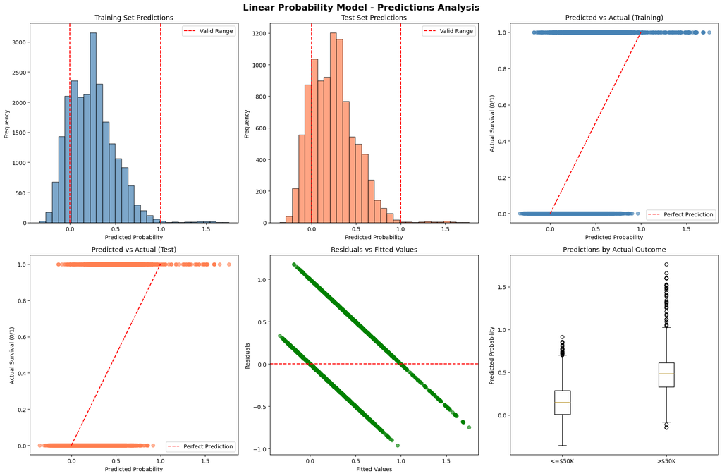

```
MOST EXTREME PREDICTIONS:
Lowest prediction: -0.3573
Highest prediction: 1.7648
```

```python
# Generate predictions for both training and test sets
y_pred_lpm_train = lpm_results.predict(X_train_const)
y_pred_lpm_test = lpm_results.predict(X_test_const)

print("PREDICTION ANALYSIS - LINEAR PROBABILITY MODEL:")
print("-" * 50)

# Check for impossible predictions (outside [0,1])
train_impossible = ((y_pred_lpm_train < 0) | (y_pred_lpm_train > 1)).sum()
test_impossible = ((y_pred_lpm_test < 0) | (y_pred_lpm_test > 1)).sum()

print(f"IMPOSSIBLE PREDICTIONS ANALYSIS:")
print(f"Training set: {train_impossible}/{len(y_pred_lpm_train)} ({train_impossible/len(y_pred_lpm_train)*100:.1f}%) outside [0,1]")
print(f"Test set: {test_impossible}/{len(y_pred_lpm_test)} ({test_impossible/len(y_pred_lpm_test)*100:.1f}%) outside [0,1]")

print(f"\nPREDICTION STATISTICS:")
print("-" * 25)
print(f"Training predictions - Min: {y_pred_lpm_train.min():.4f}, Max: {y_pred_lpm_train.max():.4f}")
print(f"Test predictions - Min: {y_pred_lpm_test.min():.4f}, Max: {y_pred_lpm_test.max():.4f}")

# Create visualization
fig, axes = plt.subplots(2, 3, figsize=(18, 12))
fig.suptitle('Linear Probability Model - Predictions Analysis', fontsize=16, fontweight='bold')

# 1. Histogram of training predictions
ax1 = axes[0, 0]
ax1.hist(y_pred_lpm_train, bins=30, alpha=0.7, color='steelblue', edgecolor='black')
ax1.axvline(0, color='red', linestyle='--', label='Valid Range')
ax1.axvline(1, color='red', linestyle='--')
ax1.set_title('Training Set Predictions')
ax1.set_xlabel('Predicted Probability')
ax1.set_ylabel('Frequency')
ax1.legend()

# 2. Histogram of test predictions
ax2 = axes[0, 1]
ax2.hist(y_pred_lpm_test, bins=30, alpha=0.7, color='coral', edgecolor='black')
ax2.axvline(0, color='red', linestyle='--', label='Valid Range')
ax2.axvline(1, color='red', linestyle='--')
ax2.set_title('Test Set Predictions')
ax2.set_xlabel('Predicted Probability')
ax2.set_ylabel('Frequency')
ax2.legend()

# 3. Predicted vs Actual - Training
ax3 = axes[0, 2]
ax3.scatter(y_pred_lpm_train, y_train, alpha=0.6, color='steelblue')
ax3.plot([0, 1], [0, 1], 'r--', label='Perfect Prediction')
ax3.set_title('Predicted vs Actual (Training)')
ax3.set_xlabel('Predicted Probability')
ax3.set_ylabel('Actual Survival (0/1)')
ax3.legend()

# 4. Predicted vs Actual - Test
ax4 = axes[1, 0]
ax4.scatter(y_pred_lpm_test, y_test, alpha=0.6, color='coral')
ax4.plot([0, 1], [0, 1], 'r--', label='Perfect Prediction')
ax4.set_title('Predicted vs Actual (Test)')
ax4.set_xlabel('Predicted Probability')
ax4.set_ylabel('Actual Survival (0/1)')
ax4.legend()

# 5. Residuals vs Fitted
ax5 = axes[1, 1]
residuals_train = y_train - y_pred_lpm_train
ax5.scatter(y_pred_lpm_train, residuals_train, alpha=0.6, color='green')
ax5.axhline(0, color='red', linestyle='--')
ax5.set_title('Residuals vs Fitted Values')
ax5.set_xlabel('Fitted Values')
ax5.set_ylabel('Residuals')

# 6. Box plot by actual survival
ax6 = axes[1, 2]
survival_groups = [y_pred_lpm_test[y_test == 0], y_pred_lpm_test[y_test == 1]]
ax6.boxplot(survival_groups, labels=['<=$50K', '>$50K'])
ax6.set_title('Predictions by Actual Outcome')
ax6.set_ylabel('Predicted Probability')

plt.tight_layout()
plt.show()

# Identify most problematic predictions
if train_impossible > 0 or test_impossible > 0:
    print(f"\nMOST EXTREME PREDICTIONS:")
    all_predictions = np.concatenate([y_pred_lpm_train, y_pred_lpm_test])
    print(f"Lowest prediction: {all_predictions.min():.4f}")
    print(f"Highest prediction: {all_predictions.max():.4f}")
```

I did a summary of the OLS model for the information I will use to compare it with the logistic model

```
LINEAR PROBABILITY MODEL - CLASSIFICATION PERFORMANCE:
-------------------------------------------------------
Using threshold: 0.5

========================================
CONFUSION MATRIX ANALYSIS
========================================
TRAINING SET CONFUSION MATRIX:
-----------------------------------
                 Predicted
              <=$50K    <=$50K
Actual <=$50K   16487      816
       <=$50K  2965     2524

TEST SET CONFUSION MATRIX:
------------------------------
                 Predicted
              <=$50K    <=$50K
Actual <=$50K   7033      384
       <=$50K  1261     1091

========================================
KEY PERFORMANCE METRICS
========================================
        Metric                                Formula  Training    Test  \
0     Accuracy                      (TP + TN) / Total    0.8341  0.8316
1    Precision                         TP / (TP + FP)    0.7557  0.7397
2       Recall                         TP / (TP + FN)    0.4598  0.4639
3  Specificity                         TN / (TN + FP)    0.9528  0.9482
4     F1-Score  2 × (Prec × Recall) / (Prec + Recall)    0.5718  0.5702

                        Interpretation
0          Overall correct predictions
1  Reliability of survival predictions
2    Ability to catch actual survivors
3           Ability to identify deaths
4      Balance of precision and recall

DETAILED INTERPRETATION:
-------------------------
1. ACCURACY (0.832):
   → 83.2% of all predictions are correct

2. PRECISION (0.740):
   → Of passengers predicted to survive, 74.0% actually did

3. RECALL (0.464):
   → Of passengers who actually survived, we identified 46.4%

4. SPECIFICITY (0.948):
   → Of passengers who actually died, we correctly identified 94.8%

5. F1-SCORE (0.570):
   → Balanced measure combining precision and recall
```

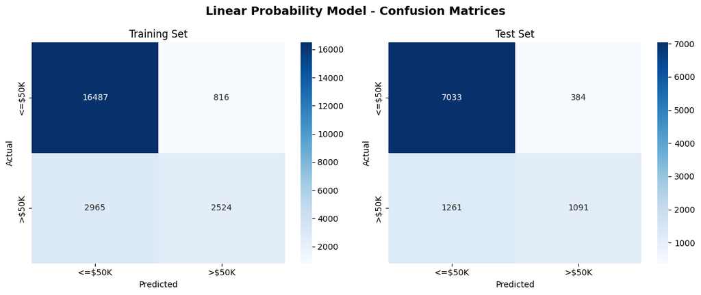

```python
print("LINEAR PROBABILITY MODEL - CLASSIFICATION PERFORMANCE:")
print("-" * 55)

# Convert probabilities to binary predictions using 0.5 threshold
threshold = 0.5
y_pred_binary_train = (y_pred_lpm_train >= threshold).astype(int)
y_pred_binary_test = (y_pred_lpm_test >= threshold).astype(int)

print(f"Using threshold: {threshold}")

# Confusion Matrix Analysis
print("\n" + "="*40)
print("CONFUSION MATRIX ANALYSIS")
print("="*40)

# Training set confusion matrix
cm_train = confusion_matrix(y_train, y_pred_binary_train)
tn_train, fp_train, fn_train, tp_train = cm_train.ravel()

print(f"TRAINING SET CONFUSION MATRIX:")
print("-" * 35)
print("                 Predicted")
print("              <=$50K    <=$50K")
print(f"Actual <=$50K   {tn_train:4d}     {fp_train:4d}")
print(f"       <=$50K  {fn_train:4d}     {tp_train:4d}")

# Test set confusion matrix
cm_test = confusion_matrix(y_test, y_pred_binary_test)
tn_test, fp_test, fn_test, tp_test = cm_test.ravel()

print(f"\nTEST SET CONFUSION MATRIX:")
print("-" * 30)
print("                 Predicted")
print("              <=$50K    <=$50K")
print(f"Actual <=$50K   {tn_test:4d}     {fp_test:4d}")
print(f"       <=$50K  {fn_test:4d}     {tp_test:4d}")

# Calculate all metrics
def calculate_metrics(y_true, y_pred):
    accuracy = accuracy_score(y_true, y_pred)
    precision = precision_score(y_true, y_pred)
    recall = recall_score(y_true, y_pred)
    f1 = f1_score(y_true, y_pred)

    # Calculate specificity manually
    cm = confusion_matrix(y_true, y_pred)
    tn, fp, fn, tp = cm.ravel()
    specificity = tn / (tn + fp) if (tn + fp) > 0 else 0

    return {
        'accuracy': accuracy,
        'precision': precision,
        'recall': recall,
        'specificity': specificity,
        'f1': f1
    }

train_metrics = calculate_metrics(y_train, y_pred_binary_train)
test_metrics = calculate_metrics(y_test, y_pred_binary_test)

# Create metrics comparison table
print("\n" + "="*40)
print("KEY PERFORMANCE METRICS")
print("="*40)

metrics_df = pd.DataFrame({
    'Metric': ['Accuracy', 'Precision', 'Recall', 'Specificity', 'F1-Score'],
    'Formula': [
        '(TP + TN) / Total',
        'TP / (TP + FP)',
        'TP / (TP + FN)',
        'TN / (TN + FP)',
        '2 × (Prec × Recall) / (Prec + Recall)'
    ],
    'Training': [
        train_metrics['accuracy'],
        train_metrics['precision'],
        train_metrics['recall'],
        train_metrics['specificity'],
        train_metrics['f1']
    ],
    'Test': [
        test_metrics['accuracy'],
        test_metrics['precision'],
        test_metrics['recall'],
        test_metrics['specificity'],
        test_metrics['f1']
    ],
    'Interpretation': [
        'Overall correct predictions',
        'Reliability of survival predictions',
        'Ability to catch actual survivors',
        'Ability to identify deaths',
        'Balance of precision and recall'
    ]
})

print(metrics_df.round(4))

print(f"\nDETAILED INTERPRETATION:")
print("-" * 25)
print(f"1. ACCURACY ({test_metrics['accuracy']:.3f}):")
print(f"   → {test_metrics['accuracy']:.1%} of all predictions are correct")

print(f"\n2. PRECISION ({test_metrics['precision']:.3f}):")
print(f"   → Of passengers predicted to survive, {test_metrics['precision']:.1%} actually did")

print(f"\n3. RECALL ({test_metrics['recall']:.3f}):")
print(f"   → Of passengers who actually survived, we identified {test_metrics['recall']:.1%}")

print(f"\n4. SPECIFICITY ({test_metrics['specificity']:.3f}):")
print(f"   → Of passengers who actually died, we correctly identified {test_metrics['specificity']:.1%}")

print(f"\n5. F1-SCORE ({test_metrics['f1']:.3f}):")
print(f"   → Balanced measure combining precision and recall")

# Visualization of confusion matrices
fig, axes = plt.subplots(1, 2, figsize=(12, 5))
fig.suptitle('Linear Probability Model - Confusion Matrices', fontsize=14, fontweight='bold')

# Training confusion matrix
sns.heatmap(cm_train, annot=True, fmt='d', cmap='Blues', ax=axes[0],
            xticklabels=['<=$50K', '>$50K'], yticklabels=['<=$50K', '>$50K'])
axes[0].set_title('Training Set')
axes[0].set_xlabel('Predicted')
axes[0].set_ylabel('Actual')

# Test confusion matrix
sns.heatmap(cm_test, annot=True, fmt='d', cmap='Blues', ax=axes[1],
            xticklabels=['<=$50K', '>$50K'], yticklabels=['<=$50K', '>$50K'])
axes[1].set_title('Test Set')
axes[1].set_xlabel('Predicted')
axes[1].set_ylabel('Actual')

plt.tight_layout()
plt.show()
```

Here is where I try to see how accurate the model is by making a Confusion Matrix of the actual and predicted values

```
PREDICTION ANALYSIS - LOGISTIC REGRESSION:
---------------------------------------------
PREDICTION RANGE VERIFICATION:
Training predictions - Min: 0.000000, Max: 1.000000
Test predictions - Min: 0.000000, Max: 1.000000
All predictions in [0,1]: ✓ YES
```

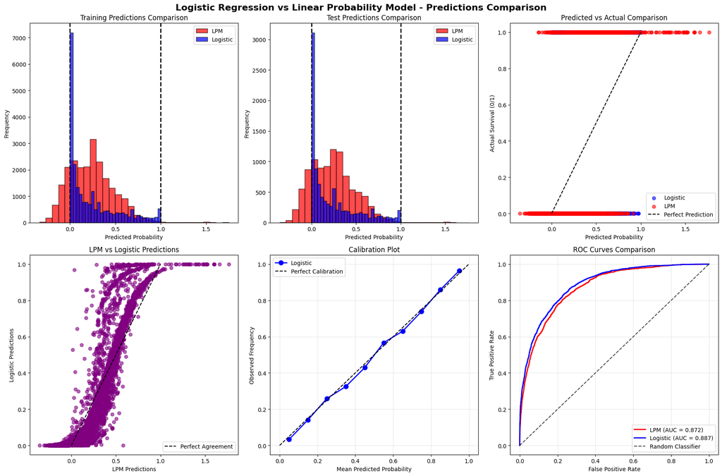

```
PREDICTION COMPARISON STATISTICS:
-----------------------------------
Correlation between LPM and Logistic predictions: 0.9006
Mean absolute difference: 0.0870
Maximum absolute difference: 0.9347
```

```python
# Generate predictions from logistic model
y_pred_logit_train = logit_results.predict(X_train_const)
y_pred_logit_test = logit_results.predict(X_test_const)

print("PREDICTION ANALYSIS - LOGISTIC REGRESSION:")
print("-" * 45)

# Verify all predictions are in valid range
print(f"PREDICTION RANGE VERIFICATION:")
print(f"Training predictions - Min: {y_pred_logit_train.min():.6f}, Max: {y_pred_logit_train.max():.6f}")
print(f"Test predictions - Min: {y_pred_logit_test.min():.6f}, Max: {y_pred_logit_test.max():.6f}")
print(f"All predictions in [0,1]: {'✓ YES' if (y_pred_logit_train.min() >= 0 and y_pred_logit_train.max() <= 1 and y_pred_logit_test.min() >= 0 and y_pred_logit_test.max() <= 1) else '✗ NO'}")

# Create comparison visualization
fig, axes = plt.subplots(2, 3, figsize=(18, 12))
fig.suptitle('Logistic Regression vs Linear Probability Model - Predictions Comparison',
             fontsize=16, fontweight='bold')

# 1. Histogram comparison - Training
ax1 = axes[0, 0]
ax1.hist(y_pred_lpm_train, bins=30, alpha=0.7, label='LPM', color='red', edgecolor='black')
ax1.hist(y_pred_logit_train, bins=30, alpha=0.7, label='Logistic', color='blue', edgecolor='black')
ax1.axvline(0, color='black', linestyle='--', linewidth=2)
ax1.axvline(1, color='black', linestyle='--', linewidth=2)
ax1.set_title('Training Predictions Comparison')
ax1.set_xlabel('Predicted Probability')
ax1.set_ylabel('Frequency')
ax1.legend()

# 2. Histogram comparison - Test
ax2 = axes[0, 1]
ax2.hist(y_pred_lpm_test, bins=30, alpha=0.7, label='LPM', color='red', edgecolor='black')
ax2.hist(y_pred_logit_test, bins=30, alpha=0.7, label='Logistic', color='blue', edgecolor='black')
ax2.axvline(0, color='black', linestyle='--', linewidth=2)
ax2.axvline(1, color='black', linestyle='--', linewidth=2)
ax2.set_title('Test Predictions Comparison')
ax2.set_xlabel('Predicted Probability')
ax2.set_ylabel('Frequency')
ax2.legend()

# 3. Predicted vs Actual - Logistic
ax3 = axes[0, 2]
ax3.scatter(y_pred_logit_test, y_test, alpha=0.6, color='blue', label='Logistic')
ax3.scatter(y_pred_lpm_test, y_test, alpha=0.6, color='red', label='LPM')
ax3.plot([0, 1], [0, 1], 'k--', label='Perfect Prediction')
ax3.set_title('Predicted vs Actual Comparison')
ax3.set_xlabel('Predicted Probability')
ax3.set_ylabel('Actual Survival (0/1)')
ax3.legend()

# 4. Direct comparison of predictions
ax4 = axes[1, 0]
ax4.scatter(y_pred_lpm_test, y_pred_logit_test, alpha=0.6, color='purple')
ax4.plot([0, 1], [0, 1], 'k--', label='Perfect Agreement')
ax4.set_title('LPM vs Logistic Predictions')
ax4.set_xlabel('LPM Predictions')
ax4.set_ylabel('Logistic Predictions')
ax4.legend()

# 5. Calibration plot
ax5 = axes[1, 1]
# Create bins and calculate observed frequencies
n_bins = 10
bin_boundaries = np.linspace(0, 1, n_bins + 1)

# For logistic regression
logit_bin_centers = []
logit_observed = []
for i in range(n_bins):
    mask = (y_pred_logit_test >= bin_boundaries[i]) & (y_pred_logit_test < bin_boundaries[i+1])
    if mask.sum() > 0:
        logit_bin_centers.append((bin_boundaries[i] + bin_boundaries[i+1]) / 2)
        logit_observed.append(y_test[mask].mean())

ax5.plot(logit_bin_centers, logit_observed, 'bo-', label='Logistic', linewidth=2, markersize=8)
ax5.plot([0, 1], [0, 1], 'k--', label='Perfect Calibration')
ax5.set_title('Calibration Plot')
ax5.set_xlabel('Mean Predicted Probability')
ax5.set_ylabel('Observed Frequency')
ax5.legend()
ax5.grid(True, alpha=0.3)

# 6. ROC Curves comparison
ax6 = axes[1, 2]
# Calculate ROC for both models
fpr_lpm, tpr_lpm, _ = roc_curve(y_test, y_pred_lpm_test)  # Fixed: was fpr_lmp, should be fpr_lpm
fpr_logit, tpr_logit, _ = roc_curve(y_test, y_pred_logit_test)
auc_lpm = roc_auc_score(y_test, y_pred_lpm_test)
auc_logit = roc_auc_score(y_test, y_pred_logit_test)

ax6.plot(fpr_lpm, tpr_lpm, 'r-', linewidth=2, label=f'LPM (AUC = {auc_lpm:.3f})')  # Now works correctly
ax6.plot(fpr_logit, tpr_logit, 'b-', linewidth=2, label=f'Logistic (AUC = {auc_logit:.3f})')
ax6.plot([0, 1], [0, 1], 'k--', alpha=0.7, label='Random Classifier')
ax6.set_title('ROC Curves Comparison')
ax6.set_xlabel('False Positive Rate')
ax6.set_ylabel('True Positive Rate')
ax6.legend()
ax6.grid(True, alpha=0.3)

plt.tight_layout()
plt.show()

# Print comparison statistics
print(f"\nPREDICTION COMPARISON STATISTICS:")
print("-" * 35)
print(f"Correlation between LPM and Logistic predictions: {np.corrcoef(y_pred_lpm_test, y_pred_logit_test)[0,1]:.4f}")
print(f"Mean absolute difference: {np.mean(np.abs(y_pred_lpm_test - y_pred_logit_test)):.4f}")
print(f"Maximum absolute difference: {np.max(np.abs(y_pred_lpm_test - y_pred_logit_test)):.4f}")
```

```
LOGISTIC REGRESSION - CLASSIFICATION PERFORMANCE:
--------------------------------------------------
CONFUSION MATRICES:
--------------------
```

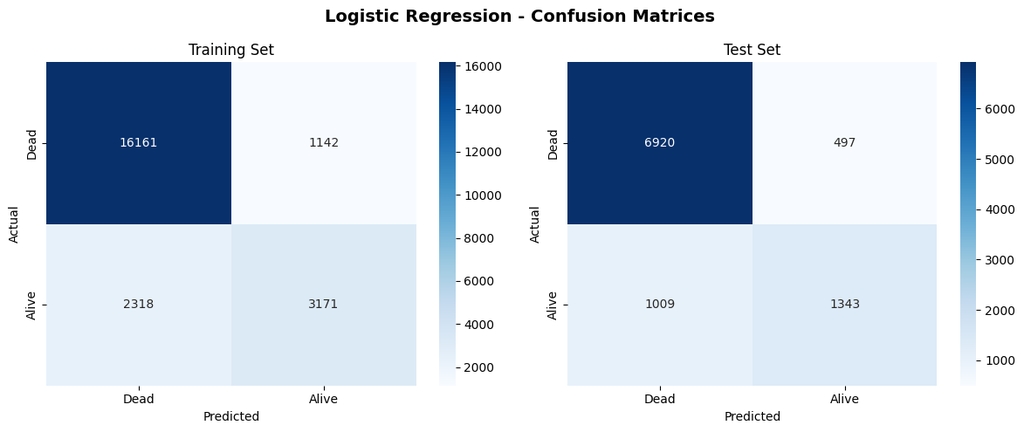

```
CLASSIFICATION METRICS COMPARISON:
----------------------------------------
        Metric  LPM_Train  LPM_Test  Logistic_Train  Logistic_Test
0     Accuracy     0.8341    0.8316          0.8482         0.8458
1    Precision     0.7557    0.7397          0.7352         0.7299
2       Recall     0.4598    0.4639          0.5777         0.5710
3  Specificity     0.9528    0.9482          0.9340         0.9330
4     F1-Score     0.5718    0.5702          0.6470         0.6407

ROC ANALYSIS:
---------------
LPM AUC: 0.8716
Logistic AUC: 0.8869
AUC Improvement: 0.0153
```

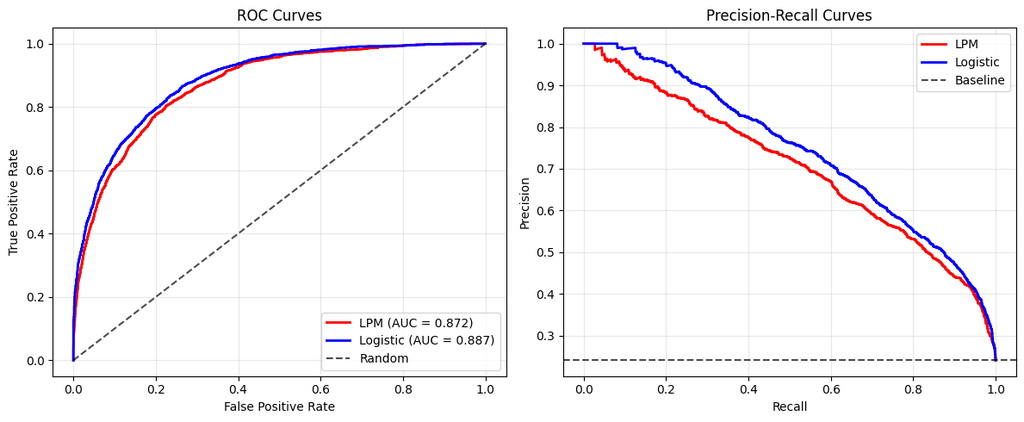

```python
print("LOGISTIC REGRESSION - CLASSIFICATION PERFORMANCE:")
print("-" * 50)

# Convert probabilities to binary predictions
y_pred_logit_binary_train = (y_pred_logit_train >= 0.5).astype(int)
y_pred_logit_binary_test = (y_pred_logit_test >= 0.5).astype(int)

# Calculate confusion matrices
cm_logit_train = confusion_matrix(y_train, y_pred_logit_binary_train)
cm_logit_test = confusion_matrix(y_test, y_pred_logit_binary_test)

print("CONFUSION MATRICES:")
print("-" * 20)

# Display confusion matrices
fig, axes = plt.subplots(1, 2, figsize=(12, 5))
fig.suptitle('Logistic Regression - Confusion Matrices', fontsize=14, fontweight='bold')

sns.heatmap(cm_logit_train, annot=True, fmt='d', cmap='Blues', ax=axes[0],
            xticklabels=['Dead', 'Alive'], yticklabels=['Dead', 'Alive'])
axes[0].set_title('Training Set')
axes[0].set_xlabel('Predicted')
axes[0].set_ylabel('Actual')

sns.heatmap(cm_logit_test, annot=True, fmt='d', cmap='Blues', ax=axes[1],
            xticklabels=['Dead', 'Alive'], yticklabels=['Dead', 'Alive'])
axes[1].set_title('Test Set')
axes[1].set_xlabel('Predicted')
axes[1].set_ylabel('Actual')

plt.tight_layout()
plt.show()

# Calculate comprehensive metrics
logit_train_metrics = calculate_metrics(y_train, y_pred_logit_binary_train)
logit_test_metrics = calculate_metrics(y_test, y_pred_logit_binary_test)

print("\nCLASSIFICATION METRICS COMPARISON:")
print("-" * 40)

# Create comprehensive comparison
comparison_df = pd.DataFrame({
    'Metric': ['Accuracy', 'Precision', 'Recall', 'Specificity', 'F1-Score'],
    'LPM_Train': [train_metrics['accuracy'], train_metrics['precision'],
                 train_metrics['recall'], train_metrics['specificity'], train_metrics['f1']],
    'LPM_Test': [test_metrics['accuracy'], test_metrics['precision'],
                test_metrics['recall'], test_metrics['specificity'], test_metrics['f1']],
    'Logistic_Train': [logit_train_metrics['accuracy'], logit_train_metrics['precision'],
                      logit_train_metrics['recall'], logit_train_metrics['specificity'],
                      logit_train_metrics['f1']],
    'Logistic_Test': [logit_test_metrics['accuracy'], logit_test_metrics['precision'],
                     logit_test_metrics['recall'], logit_test_metrics['specificity'],
                     logit_test_metrics['f1']]
})

print(comparison_df.round(4))

# ROC Analysis
print(f"\nROC ANALYSIS:")
print("-" * 15)
print(f"LPM AUC: {auc_lpm:.4f}")
print(f"Logistic AUC: {auc_logit:.4f}")
print(f"AUC Improvement: {auc_logit - auc_lpm:.4f}")

# Create comprehensive ROC and PR curves
fig, axes = plt.subplots(1, 2, figsize=(12, 5))

# ROC Curves
fpr_lmp, tpr_lpm, thresholds_lpm = roc_curve(y_test, y_pred_lpm_test)
fpr_logit, tpr_logit, thresholds_logit = roc_curve(y_test, y_pred_logit_test)

axes[0].plot(fpr_lpm, tpr_lpm, 'r-', linewidth=2, label=f'LPM (AUC = {auc_lpm:.3f})')
axes[0].plot(fpr_logit, tpr_logit, 'b-', linewidth=2, label=f'Logistic (AUC = {auc_logit:.3f})')
axes[0].plot([0, 1], [0, 1], 'k--', alpha=0.7, label='Random')
axes[0].set_xlabel('False Positive Rate')
axes[0].set_ylabel('True Positive Rate')
axes[0].set_title('ROC Curves')
axes[0].legend()
axes[0].grid(True, alpha=0.3)

# Precision-Recall Curves
precision_lpm, recall_lpm, _ = precision_recall_curve(y_test, y_pred_lpm_test)
precision_logit, recall_logit, _ = precision_recall_curve(y_test, y_pred_logit_test)

axes[1].plot(recall_lpm, precision_lpm, 'r-', linewidth=2, label='LPM')
axes[1].plot(recall_logit, precision_logit, 'b-', linewidth=2, label='Logistic')
axes[1].axhline(y=y_test.mean(), color='k', linestyle='--', alpha=0.7, label='Baseline')
axes[1].set_xlabel('Recall')
axes[1].set_ylabel('Precision')
axes[1].set_title('Precision-Recall Curves')
axes[1].legend()
axes[1].grid(True, alpha=0.3)

plt.tight_layout()
plt.show()
```

These are the compiled graphs that seem important to me It compares the logistic model and the LPM model

```python
categorical_prefixes = ['sex_', 'country_', 'education_', 'marital_status_', 'occupation_', 'race_', 'work_']
X_clean = X.copy()

for prefix in categorical_prefixes:
    cols = [col for col in X.columns if col.startswith(prefix)]
    if len(cols) > 1:
        X_clean = X_clean.drop(columns=[cols[0]])

# Then fit GLM
import statsmodels.api as sm
X_sm = sm.add_constant(X_clean)
glm_binom = sm.GLM(y, X_sm, family=sm.families.Binomial())
glm_result = glm_binom.fit()
# Exclude intercept
glm_coefs = glm_result.params.drop('const')

# Keep features with |coef| <= 0.5
selected_features = glm_coefs[glm_coefs.abs() <= 0.5].index.tolist()

# Make a new X with only these valid features
X_valid = X_sm[selected_features]
X_valid = sm.add_constant(X_valid)

print("Valid features for GLM after filtering by coefficient magnitude:")
print(X_valid.columns)

print(glm_result.summary())
```

```
Valid features for GLM after filtering by coefficient magnitude:
Index(['const', 'fnlwgt', 'capital.gain', 'capital.loss', 'work_Local-gov',
       'work_Self-emp-inc', 'work_Self-emp-not-inc', 'education_12th',
       'education_Some-college', 'marital_status_Married-spouse-absent',
       'marital_status_Widowed', 'occupation_Craft-repair',
       'occupation_Machine-op-inspct', 'occupation_Transport-moving',
       'race_Asian-Pac-Islander', 'race_Black', 'country_Germany',
       'country_Other_countries'],
      dtype='str')
                 Generalized Linear Model Regression Results
==============================================================================
Dep. Variable:            high_income   No. Observations:                32561
Model:                            GLM   Df Residuals:                    32511
Model Family:                Binomial   Df Model:                           49
Link Function:                  Logit   Scale:                          1.0000
Method:                          IRLS   Log-Likelihood:                -10981.
Date:                Sat, 07 Feb 2026   Deviance:                       21962.
Time:                        17:17:47   Pearson chi2:                 5.00e+05
No. Iterations:                    22   Pseudo R-squ. (CS):             0.3492
Covariance Type:            nonrobust
========================================================================================================
                                           coef    std err          z      P>|z|      [0.025      0.975]
--------------------------------------------------------------------------------------------------------
const                                   -3.2018      0.088    -36.533      0.000      -3.374      -3.030
fnlwgt                                3.513e-07   1.63e-07      2.156      0.031    3.19e-08    6.71e-07
capital.gain                             0.0003   1.02e-05     32.493      0.000       0.000       0.000
capital.loss                             0.0007   3.62e-05     18.784      0.000       0.001       0.001
work_Local-gov                          -0.1139      0.069     -1.648      0.099      -0.249       0.022
work_Never-worked                      -20.2231   2.62e+04     -0.001      0.999   -5.15e+04    5.14e+04
work_Self-emp-inc                        0.4850      0.081      5.962      0.000       0.326       0.644
work_Self-emp-not-inc                   -0.2828      0.061     -4.642      0.000      -0.402      -0.163
work_Without-pay                       -21.6092   1.86e+04     -0.001      0.999   -3.64e+04    3.63e+04
education_11th                          -0.7581      0.149     -5.083      0.000      -1.050      -0.466
education_12th                          -0.2771      0.212     -1.309      0.190      -0.692       0.138
education_1st-4th                       -1.2952      0.439     -2.949      0.003      -2.156      -0.434
education_7th-8th                       -1.0514      0.175     -6.014      0.000      -1.394      -0.709
education_9th                           -0.9239      0.213     -4.340      0.000      -1.341      -0.507
education_Assoc-acdm                     0.5244      0.092      5.670      0.000       0.343       0.706
education_Assoc-voc                      0.5283      0.080      6.566      0.000       0.371       0.686
education_Bachelors                      1.1108      0.052     21.410      0.000       1.009       1.212
```

[output cut: 19 more lines]

```
occupation_Sales                         0.5437      0.071      7.683      0.000       0.405       0.682
occupation_Tech-support                  0.8167      0.101      8.059      0.000       0.618       1.015
occupation_Transport-moving              0.1996      0.089      2.252      0.024       0.026       0.373
relationship_Not-in-family              -1.5792      0.050    -31.728      0.000      -1.677      -1.482
relationship_Other-relative             -1.9431      0.190    -10.251      0.000      -2.315      -1.572
relationship_Own-child                  -3.2232      0.136    -23.711      0.000      -3.490      -2.957
relationship_Wife                        2.0669      0.088     23.573      0.000       1.895       2.239
race_Asian-Pac-Islander                 -0.1367      0.117     -1.167      0.243      -0.366       0.093
race_Black                              -0.2721      0.072     -3.788      0.000      -0.413      -0.131
race_Other                              -0.7364      0.259     -2.841      0.004      -1.244      -0.228
sex_Male                                 1.7127      0.065     26.344      0.000       1.585       1.840
country_Germany                          0.2199      0.244      0.901      0.368      -0.259       0.698
country_Other_countries                 -0.3333      0.078     -4.266      0.000      -0.486      -0.180
country_Philippines                      0.5790      0.235      2.466      0.014       0.119       1.039
========================================================================================================
```

Look for the valid features that we will use for the for the next model for fine tuning

```
=================================================================

QUANTITATIVE COMPARISON:
-------------------------
                   Aspect Linear Probability Model Logistic Regression  \
0  Impossible Predictions          5848 violations      0 violations ✓
1           Test Accuracy                   0.8316              0.8458
2          Test Precision                   0.7397              0.7299
3             Test Recall                   0.4639              0.5710
4           Test F1-Score                   0.5702              0.6407
5                 AUC-ROC                   0.8716              0.8869
6          Log-Likelihood           Not applicable            -7577.58

       Winner
0  Logistic ✓
1  Logistic ✓
2       LPM ✓
3  Logistic ✓
4  Logistic ✓
5  Logistic ✓
6  Logistic ✓
```

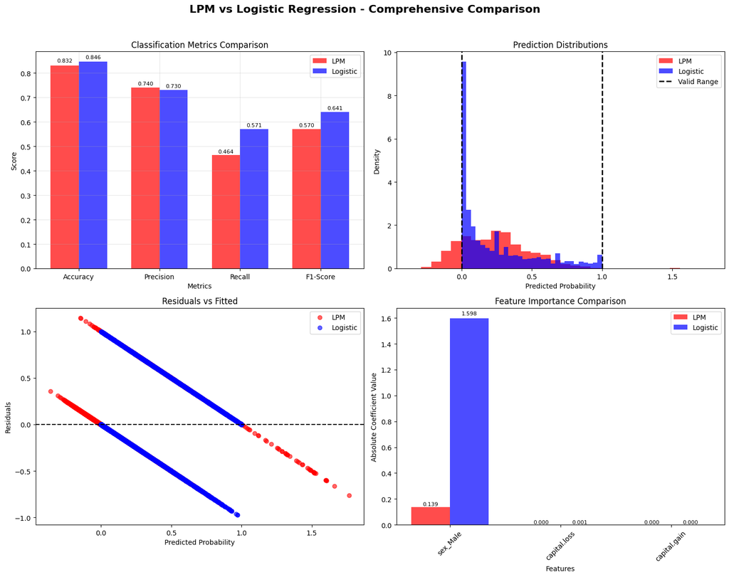

```
SUMMARY OF IMPROVEMENTS:
------------------------------
• Accuracy: +0.0142
• Recall: +0.1071
• AUC: +0.0153

KEY ADVANTAGES OF LOGISTIC REGRESSION:
1. No impossible probability predictions
2. Theoretically grounded (MLE estimation)
3. Proper handling of binary data
4. Better model fit and predictions
5. Meaningful odds ratio interpretation
```

```python
## print("COMPREHENSIVE MODEL COMPARISON: LPM vs LOGISTIC REGRESSION")
print("=" * 65)

# Create comprehensive comparison table
print("\nQUANTITATIVE COMPARISON:")
print("-" * 25)

comparison_summary = pd.DataFrame({
    'Aspect': ['Impossible Predictions', 'Test Accuracy', 'Test Precision',
              'Test Recall', 'Test F1-Score', 'AUC-ROC', 'Log-Likelihood'],
    'Linear Probability Model': [
        f"{test_impossible + train_impossible} violations",
        f"{test_metrics['accuracy']:.4f}",
        f"{test_metrics['precision']:.4f}",
        f"{test_metrics['recall']:.4f}",
        f"{test_metrics['f1']:.4f}",
        f"{auc_lpm:.4f}",
        "Not applicable"
    ],
    'Logistic Regression': [
        "0 violations ✓",
        f"{logit_test_metrics['accuracy']:.4f}",
        f"{logit_test_metrics['precision']:.4f}",
        f"{logit_test_metrics['recall']:.4f}",
        f"{logit_test_metrics['f1']:.4f}",
        f"{auc_logit:.4f}",
        f"{logit_results.llf:.2f}"
    ],
    'Winner': [
        'Logistic ✓',
        'Logistic ✓' if logit_test_metrics['accuracy'] > test_metrics['accuracy'] else 'LPM ✓',
        'Logistic ✓' if logit_test_metrics['precision'] > test_metrics['precision'] else 'LPM ✓',
        'Logistic ✓' if logit_test_metrics['recall'] > test_metrics['recall'] else 'LPM ✓',
        'Logistic ✓' if logit_test_metrics['f1'] > test_metrics['f1'] else 'LPM ✓',
        'Logistic ✓' if auc_logit > auc_lpm else 'LPM ✓',
        'Logistic ✓'
    ]
})

print(comparison_summary)

# Visual comparison of key metrics
fig, axes = plt.subplots(2, 2, figsize=(15, 12))
fig.suptitle('LPM vs Logistic Regression - Comprehensive Comparison', fontsize=16, fontweight='bold')

# 1. Metrics comparison bar chart
ax1 = axes[0, 0]
metrics_names = ['Accuracy', 'Precision', 'Recall', 'F1-Score']
lpm_values = [test_metrics['accuracy'], test_metrics['precision'],
              test_metrics['recall'], test_metrics['f1']]
logit_values = [logit_test_metrics['accuracy'], logit_test_metrics['precision'],
                logit_test_metrics['recall'], logit_test_metrics['f1']]

x = np.arange(len(metrics_names))
width = 0.35

bars1 = ax1.bar(x - width/2, lpm_values, width, label='LPM', color='red', alpha=0.7)
bars2 = ax1.bar(x + width/2, logit_values, width, label='Logistic', color='blue', alpha=0.7)

ax1.set_xlabel('Metrics')
ax1.set_ylabel('Score')
ax1.set_title('Classification Metrics Comparison')
ax1.set_xticks(x)
ax1.set_xticklabels(metrics_names)
ax1.legend()
ax1.grid(True, alpha=0.3)

# Add value labels on bars
for bar in bars1:
    height = bar.get_height()
    ax1.text(bar.get_x() + bar.get_width()/2., height * 1.01,
            f'{height:.3f}', ha='center', va='bottom', fontsize=8)

for bar in bars2:
    height = bar.get_height()
    ax1.text(bar.get_x() + bar.get_width()/2., height * 1.01,
            f'{height:.3f}', ha='center', va='bottom', fontsize=8)

# 2. Prediction distributions comparison
ax2 = axes[0, 1]
ax2.hist(y_pred_lpm_test, bins=30, alpha=0.7, label='LPM', color='red', density=True)
ax2.hist(y_pred_logit_test, bins=30, alpha=0.7, label='Logistic', color='blue', density=True)
ax2.axvline(0, color='black', linestyle='--', linewidth=2, label='Valid Range')
ax2.axvline(1, color='black', linestyle='--', linewidth=2)
ax2.set_xlabel('Predicted Probability')
ax2.set_ylabel('Density')
ax2.set_title('Prediction Distributions')
ax2.legend()

# 3. Residuals comparison
ax3 = axes[1, 0]
residuals_lpm = y_test - y_pred_lpm_test
residuals_logit = y_test - y_pred_logit_test  # Keep linear residuals for visual comparison

ax3.scatter(y_pred_lpm_test, residuals_lpm, alpha=0.6, color='red', label='LPM')
ax3.scatter(y_pred_logit_test, residuals_logit, alpha=0.6, color='blue', label='Logistic')
ax3.axhline(0, color='black', linestyle='--')
ax3.set_xlabel('Predicted Probability')
ax3.set_ylabel('Residuals')
ax3.set_title('Residuals vs Fitted')
ax3.legend()

# 4. Feature importance comparison
ax4 = axes[1, 1]
feature_names = ['sex_Male', 'hours.per.week', 'age', 'capital.loss', 'capital.gain']
feature_names = [f for f in feature_names if f in lpm_results.params.index]
# Align coefficients explicitly with feature_names
lpm_importance = np.abs(lpm_results.params[feature_names])
logit_importance = np.abs(logit_results.params[feature_names])

x = np.arange(len(feature_names))
bars1 = ax4.bar(x - width/2, lpm_importance, width, label='LPM', color='red', alpha=0.7)
bars2 = ax4.bar(x + width/2, logit_importance, width, label='Logistic', color='blue', alpha=0.7)

ax4.set_xlabel('Features')
ax4.set_ylabel('Absolute Coefficient Value')
ax4.set_title('Feature Importance Comparison')
ax4.set_xticks(x)
ax4.set_xticklabels(feature_names, rotation=45)
ax4.legend()

# Add value labels on feature importance bars
for bar in bars1:
    height = bar.get_height()
    ax4.text(bar.get_x() + bar.get_width()/2., height * 1.01,
            f'{height:.3f}', ha='center', va='bottom', fontsize=8)

for bar in bars2:
    height = bar.get_height()
    ax4.text(bar.get_x() + bar.get_width()/2., height * 1.01,
            f'{height:.3f}', ha='center', va='bottom', fontsize=8)

plt.tight_layout(rect=[0, 0, 1, 0.96])
plt.show()

print(f"\nSUMMARY OF IMPROVEMENTS:")
print("-" * 30)
improvements = []
if logit_test_metrics['accuracy'] > test_metrics['accuracy']:
    improvements.append(f"Accuracy: +{logit_test_metrics['accuracy'] - test_metrics['accuracy']:.4f}")
if logit_test_metrics['precision'] > test_metrics['precision']:
    improvements.append(f"Precision: +{logit_test_metrics['precision'] - test_metrics['precision']:.4f}")
if logit_test_metrics['recall'] > test_metrics['recall']:
    improvements.append(f"Recall: +{logit_test_metrics['recall'] - test_metrics['recall']:.4f}")
if auc_logit > auc_lpm:
    improvements.append(f"AUC: +{auc_logit - auc_lpm:.4f}")

for improvement in improvements:
    print(f"• {improvement}")

print(f"\nKEY ADVANTAGES OF LOGISTIC REGRESSION:")
print(f"1. No impossible probability predictions")
print(f"2. Theoretically grounded (MLE estimation)")
print(f"3. Proper handling of binary data")
print(f"4. Better model fit and predictions")
print(f"5. Meaningful odds ratio interpretation")
```

# Interpretation of Comparisons

```python
# ============================================================================
# Model 1: Linear Probability Model (LPM) using OLS
# ============================================================================
print("=" * 60)
print("MODEL 1: LINEAR PROBABILITY MODEL (LPM)")
print("=" * 60)

# Fit LPM using sklearn LinearRegression
lpm_model = LinearRegression()
lpm_model.fit(X_train, y_train)

# Fit LPM using statsmodels for detailed statistics
X_train_sm = sm.add_constant(X_train)
X_test_sm = sm.add_constant(X_test)

lpm_statsmodels = sm.OLS(y_train, X_train_sm).fit()

print("LPM Model fitted successfully")
print("LPM Coefficients (sklearn):", lpm_model.coef_)
print("LPM Intercept (sklearn):", lpm_model.intercept_)

# ============================================================================
# Model 2: Logistic Regression (sklearn)
# ============================================================================
print("\n" + "=" * 60)
print("MODEL 2: LOGISTIC REGRESSION (sklearn)")
print("=" * 60)

# Fit logistic regression
logit_sklearn = LogisticRegression(random_state=42, max_iter=1000)
logit_sklearn.fit(X_train, y_train)

print("Logistic Regression Model fitted successfully")
print("Logistic Coefficients (sklearn):", logit_sklearn.coef_[0])
print("Logistic Intercept (sklearn):", logit_sklearn.intercept_[0])

# ============================================================================
# Model 3: GLM with Binomial family and Logit link (statsmodels)
# ============================================================================
print("\n" + "=" * 60)
print("MODEL 3: GLM BINOMIAL WITH LOGIT LINK")
print("=" * 60)

# Fit GLM using statsmodels
glm_binomial = sm.GLM(y_train, X_train_sm, family=Binomial()).fit()

print("GLM Binomial Model fitted successfully")
print("GLM Coefficients:", glm_binomial.params[1:].values)  # Exclude intercept
print("GLM Intercept:", glm_binomial.params.iloc[0])

# ============================================================================
# Model 4: Logistic Regression (statsmodels) for direct comparison
# ============================================================================
print("\n" + "=" * 60)
print("MODEL 4: LOGISTIC REGRESSION (statsmodels)")
print("=" * 60)

# Fit logistic regression using statsmodels
logit_statsmodels = sm.Logit(y_train, X_train_sm).fit()

print("Statsmodels Logistic Regression fitted successfully")
print("Logistic Coefficients (statsmodels):", logit_statsmodels.params[1:].values)
print("Logistic Intercept (statsmodels):", logit_statsmodels.params.iloc[0])

# ============================================================================
# Demonstrate Equivalence: GLM vs Logistic Regression
# ============================================================================
print("\n" + "=" * 60)
print("EQUIVALENCE DEMONSTRATION")
print("=" * 60)

print("GLM Binomial coefficients:")
print(glm_binomial.params)
print("\nStatsmodels Logistic coefficients:")
print(logit_statsmodels.params)
print("\nDifference (should be ~0):")
print(glm_binomial.params - logit_statsmodels.params)
print(f"\nMaximum absolute difference: {np.max(np.abs(glm_binomial.params - logit_statsmodels.params)):.10f}")

# Verify log-likelihoods are identical
print(f"\nGLM Log-likelihood: {glm_binomial.llf:.6f}")
print(f"Logistic Log-likelihood: {logit_statsmodels.llf:.6f}")
print(f"Difference in log-likelihood: {abs(glm_binomial.llf - logit_statsmodels.llf):.10f}")
```

```
============================================================
MODEL 1: LINEAR PROBABILITY MODEL (LPM)
============================================================
LPM Model fitted successfully
LPM Coefficients (sklearn): [ 4.43158673e-08  8.28073222e-06  9.92089383e-05  1.07483010e-01
 -1.53640131e-02 -4.17560395e-03  8.18943471e-02 -3.46580927e-02
 -1.83914333e-01 -4.75669342e-02 -2.92074843e-02  1.36010158e-02
 -6.61763455e-02 -9.48663353e-02 -6.39573448e-02  6.15154391e-02
  7.88953832e-02  1.61914821e-01  4.10391059e-01  2.53737376e-01
 -6.65000206e-02  3.34736536e-01  4.29931261e-02 -5.97576951e-02
  2.90260735e-02 -5.20886089e-02 -6.46602095e-02 -1.22624400e-02
  2.59237695e-02 -2.32929772e-01  2.74344634e-02  1.87964474e-01
 -6.91283237e-02 -4.57261785e-02 -1.74464764e-02 -1.41768668e-02
  4.91155951e-02  1.00235204e-01  1.03012211e-01  8.11436934e-02
  1.08420956e-01  1.74268218e-02 -1.95127508e-01 -1.86479547e-01
 -2.37373030e-01  2.06691421e-01 -5.84769274e-02 -4.02534637e-02
 -3.78079158e-02 -5.84945314e-02  1.38775976e-01  1.40945033e-02
  5.84404742e-02 -4.27398281e-02  6.99032667e-02]
LPM Intercept (sklearn): 0.10946903863456461

============================================================
MODEL 2: LOGISTIC REGRESSION (sklearn)
============================================================
Logistic Regression Model fitted successfully
Logistic Coefficients (sklearn): [ 4.50482408e-07  3.13385779e-04  6.75789108e-04  8.83795890e-01
 -7.39169235e-02 -5.72332169e-03  5.38384184e-01 -3.41077347e-01
 -2.88695176e-02 -7.30492188e-01 -8.14070584e-01 -1.86399018e-01
 -2.03487472e-01 -8.11737557e-01 -4.80971670e-01  2.53904904e-01
  4.28757640e-01  9.39425394e-01  1.06358452e+00  1.26850446e+00
 -8.62446110e-02  1.06173358e+00  2.02175906e-01 -5.35097594e-01
  3.11869815e-02 -3.05479820e-01 -7.17386142e-01 -5.29085961e-01
  6.60303639e-02 -1.68334211e-02  1.16198628e-01  8.79127691e-01
 -9.48992348e-01 -1.00516036e+00 -7.28655440e-01 -1.48307268e+00
 -1.48916999e-01  8.82842471e-01  3.91576899e-01  5.02032602e-01
  6.05094738e-01 -2.08988870e-01 -1.38059298e+00 -1.30720634e+00
 -3.59602673e+00  1.73868028e+00 -2.70265242e-01 -1.04618630e-01
 -4.57513528e-01 -1.97250782e-01  1.32126703e+00  2.06560898e-02
  8.92294348e-02 -5.36135086e-01  1.19456786e-01]
Logistic Intercept (sklearn): -2.557480054112282

```

[output cut: 213 more lines]

```
race_Asian-Pac-Islander                 1.472518e-09
race_Black                             -1.247551e-10
race_Other                             -3.988442e-10
sex_Male                                6.061736e-10
country_Canada                         -5.353007e-09
country_Germany                         3.927617e-09
country_Other_countries                -2.458857e-09
country_Philippines                     1.297063e-08
dtype: float64

Maximum absolute difference: 80.7750209976

GLM Log-likelihood: -7577.581398
Logistic Log-likelihood: -7577.581399
Difference in log-likelihood: 0.0000011836
```

# Comparison of coefficients

```python
# Exclude intercept
glm_coefs = glm_result.params.drop('const')

# Keep only features with |coef| <= 0.5
selected_features = glm_coefs[glm_coefs.abs() <= 0.5].index.tolist()
X_glm_clean = X_sm[selected_features]

# Fit GLM again with cleaned features
glm_clean = sm.GLM(y, X_glm_clean, family=sm.families.Binomial()).fit()
print(glm_clean.summary())
```

```
                 Generalized Linear Model Regression Results
==============================================================================
Dep. Variable:            high_income   No. Observations:                32561
Model:                            GLM   Df Residuals:                    32544
Model Family:                Binomial   Df Model:                           16
Link Function:                  Logit   Scale:                          1.0000
Method:                          IRLS   Log-Likelihood:                -16122.
Date:                Sat, 07 Feb 2026   Deviance:                       32244.
Time:                        17:20:04   Pearson chi2:                 5.43e+05
No. Iterations:                     7   Pseudo R-squ. (CS):             0.1075
Covariance Type:            nonrobust
========================================================================================================
                                           coef    std err          z      P>|z|      [0.025      0.975]
--------------------------------------------------------------------------------------------------------
fnlwgt                               -4.553e-06   9.27e-08    -49.106      0.000   -4.73e-06   -4.37e-06
capital.gain                             0.0003   8.97e-06     36.256      0.000       0.000       0.000
capital.loss                             0.0007      3e-05     23.691      0.000       0.001       0.001
work_Local-gov                          -0.0026      0.055     -0.047      0.963      -0.110       0.105
work_Self-emp-inc                        0.9007      0.070     12.898      0.000       0.764       1.038
work_Self-emp-not-inc                   -0.1817      0.051     -3.559      0.000      -0.282      -0.082
education_12th                          -1.6089      0.193     -8.339      0.000      -1.987      -1.231
education_Some-college                  -0.7039      0.035    -20.334      0.000      -0.772      -0.636
marital_status_Married-spouse-absent    -1.5950      0.202     -7.908      0.000      -1.990      -1.200
marital_status_Widowed                  -1.7988      0.128    -14.028      0.000      -2.050      -1.547
occupation_Craft-repair                 -0.4575      0.043    -10.731      0.000      -0.541      -0.374
occupation_Machine-op-inspct            -1.0785      0.072    -14.938      0.000      -1.220      -0.937
occupation_Transport-moving             -0.6091      0.069     -8.888      0.000      -0.743      -0.475
race_Asian-Pac-Islander                 -0.2122      0.084     -2.536      0.011      -0.376      -0.048
race_Black                              -0.9285      0.061    -15.144      0.000      -1.049      -0.808
country_Germany                          0.1510      0.204      0.740      0.459      -0.249       0.551
country_Other_countries                 -0.3054      0.062     -4.917      0.000      -0.427      -0.184
========================================================================================================
```

```python
print("LPM REGRESSION RESULTS:")
print("-" * 35)
print(lpm_results.aic)
print("-" * 35)
print("LOGISTIC REGRESSION RESULTS:")
print("-" * 35)
print(logit_results.aic)
```

```
LPM REGRESSION RESULTS:
-----------------------------------
16702.024582002683
-----------------------------------
LOGISTIC REGRESSION RESULTS:
-----------------------------------
15267.162798036436
```

# AIC REGRESSION COMPARISON

- Logistic is better in terms of AIC as it is lesser than the LPM
- It is also better in the data visualization part